# Chapter 2: Statistical Modeling

**Miscellaneous**<sup>Return</sup>

*Run* = *Ctrl+Shift+Enter*  
*Insert Chunk* =*Ctrl+Alt+I*  
*Preview*=*Ctrl+Shift+K*

- μ = mean of normal distribution
- θ = multiple parameters for probability model
  - ex) binomial model θ=(n,p) -> 2 numbers n=positive integer & p=real number between 0 & 1
- **Observed variables**
  - measured numbers (including gender)-> datafiles
  - discrete or continous
  - Subclassification
    - exogenous variable = ~independent variable -> not controlled by other variables
    - endogenous variable = ~dependent variable -> controlled by other variables
    - Dichotomous -> binary output of 1 or 0
  - Latent vs observed variable
    - Latent = hidden non-observed
- **Expected Value**
  - “the output from some action”
    - Expected value of random variable = mean of the random variable
  - Basic formula
    - **(Probability P(x))(#times of event) = expected value**
    - formula changes depending on event
    - Formula for Binomial random variable = basic formula
    - Formula for Multiple events
      - E(X) = ∑ P(X)(n)
  - Formula for continous random variables
- **Probability Distribution**
  - Tells probability of event happening
    - simple events (coin toss) & complex events (drug success)
  - Types
    - Basic probability distributions -> probability distribution table
    - Binomial distribution -> pass/fail
    - Normal distribution -> Bell curve
  - Display via table/graph/formula
  - Family/List
    - Discrete probability distribution
      - probability distributions (binomial, normal, Poisson) -> classified as continous or discrete
        - Discrete distribtuion = discrete random variables
      - examples
        - Binomial, Geometric, Hypergeometric, Multinomial, Negative Binomial, Poisson
    - Beta Distribution
      - Represent outcomes for percentages/proportions
      - 3 Betas associated /w function
        - Beta(α, β)= the name of the probability distribution
        - B(α, β ) = the name of function in denomiantor of probability distribution function
          - normalizing constant to ensure area under curve of probability distribution function =1
        - β= the name of the second shape parameter in the probability distribution function
          - > α and β are two positive shape parameters which control the shape of the distribution.
          - > For example, if α < 1 and Β < 1, the graph’s shape will be a “U”
          - > if α = 1 and Β = 2, the graph is a straight line
        - so alpha and beta parameters control the shape of this function
    - [Beta-Binomial Distribution & Beta-Bernoulli Distribution](https://www.statisticshowto.datasciencecentral.com/beta-binomial-distribution/)
      - Mixture of beta distribution + binomial distribution
      - Simplist model for Bayesian statistics
      - > A distribution is beta-binomial if p, the probability of success, in a binomial distribution has a beta distribution with shape parameters α > 0 and β > 0. The shape parameters define the probability of success.
        - Large alpha and beta -> approach binomial distribution
        - If alpha and beta = 1 then distribution is discrete(finite) uniform from 0 to n
        - If n=1 then Bernoulli distribution
      - Binomial vs Beta-binomial
        - Binomial p-value fixed for set of trials
        - Beta-binomial p-value non-fixed and differs from trial to trial
- **Monte Carlo Simulation Method**
  - Stochastic Model -> uncertainty is present = model for randomness
  - account for risk when making decision/quantitative analysis
  - Finds all possible outcomes of decision & assess risk
  - Used for statistical sampling methods which are complex
    - Input model simulated >100 times
      - end simulations are equally likely
      - results in probability distribution of possible outcomes
        - one/many different distributions (chi, normal, uniform, etc)
    - Transforms numbers from random number generators -> seqs of transformed numbers repeat after certain #of samples
      - error calculation(mean) does not remove errors
        - Violate Central Limit Theorem & Law of Large #’s
      - **Output of Monte Carlo simulations are approximates (5-10% error)** never precise
    - Tells
      - All possible events that could/will happen
      - Probability of each outcome
    - Quantified probability
      - Returned by MC simulation -> gives scenarios w/ numbers
    - Accuracy
      - MC can be accurate but never precise because
        - Large amounts of data involved
        - Unknowns in system
        - Probability based -> random prediction = margin of error in results
      - Resons leading to running bad MC simulation
        - Using incorrect model/unrealistic probability distribution
        - Risk factors not complete (unspecified variables)
        - MC isn’t suitable for data
        - Random #generator used is not good enough
- **Chi-Square statistic**
  - Can only use on numbers, not precentages, proportions, or mean (ex) bad->10% of 200 people = 20people <-good)
  - 2 types of tests - both use statistic + distribution
    - Goodness of fit test = see if data matches a population
    - test for independence = compare 2 variables in contingency table & see if related (see if distributions of categorical vars differ)
      - Small chi test statistic = observed data fits expected data well (relationship)
      - Large chi statistic = data doesn’t fit well (no relationship)
  - Chi statistic
    - c = degrees of freedom
    - O = observed value
    - E = expected value
  - Show relationship between categorical variables (non-numerical)
    - Tells how much difference there is between observed counts if no relationship in population
      - Low value = high correlation between 2 sets of data
      - X^2 = 0 means observed values=expected values
    - Need to compare chi value to critical value from table
      - **If X^2 > critical value == significant difference between observed & expected**
      - Or use p-value w/ H0 and HA hypothesis
        - Small p-values = significant difference
          - Need chi degrees of freedom (n-1)
          - Need alpha level (0.10, 0.05, or 0.01) -> 10%, 5%, 1%
- **Maximum Likelihood Estimate**
  - Finds most likely function to explain observed data
    - ex) Given model to find probabilities (find prob X >2 if Poisson(2.4) distributed)
      - parameter of lambda = 2.4
      - what if model not given for data & need to fit data to model? -> use MLE
  - MLE takes known probability distributions & compares your dataset to find good fitting match
    - Distribtuions can have infinite #of parameters
      - **MLE finds the parameter of the population & most likely generates sample tested**
      - Match data to distribution = goodness of fit
  - MLE function
    - Likelihood of a sample = probability of getting the sample under a distribution model
      - Likelihood function expresses the probability
      - parameters maximizing probability of getting the sample = MLE
    - ex) set of random variables(X) taken from unknown population distribution w/ parameter theta
      - Distribtuion has probability density function f(X|theta)
        - f = model
        - X=set of random vars
        - Theta=unknown parameter
      - MLE function finds most likely value for theta when given X random variables

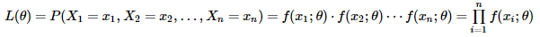

- **Goodness of Fit Test**
  - Test if sample data fits distribution for a certain population (see if sample data represents data in population)
  - **Common types**
    - Chi-square
      - Discrete distributions (binomial, Poisson)
      - Problem
        - can only be used for data classifed into classes(bins) -> need to make freq table/histogram
        - **Needs large sample size for close approximation**
      - 2 types
        - Test for independence = compares 2 sets of data to see if there is a relationship
        - Goodness of fit = fit one categorical variable to distribution
    - Kolmogorov-Smirnov
      - Continuous distributions
      - Test for normallity
        - Tells when it’s unlikely the data follows a normal distribution
        - Doesn’t make assumptions of the distribtion of the data
      - Problem
        - Doesn’t tell if particular sample came from a normal population
    - Anderson-Darling
      - Continuous distributions
      - Modification of Kolmogorov-Smirnov
      - Tells if data is unlikely to have normal distribution
      - More sensitive to deviations in distribution
    - Shipiro-Wilk
      - Calculates W-value to see if random sample came from normal population distribution
      - Recommends samples up to n=2000
- **Bayesian Statistics/infererence & probability**
  - Statistics using prior probabilities to answer
    - Has an event occured before?
    - Will the event occur based upon current knowledge?
  - Prior probability = probability distribution summarizing beliefs of an event before(prior) new evidence considered
    - Adding new evidence = posterior probability
  - Examples using Bayesian probabilities
    - Bayes Theorem
    - Inverse Probability